# A Basic Linear Regression With Stan

Ben K. Margetts

ben.margetts.14@ucl.ac.uk

UCL Great Ormond Street Institute of Child Health

# Read-in Our Libraries:

Read-in ‘rstan’, ‘knitr’, and ‘ggplot2’. Configure rstan to run on all available cores of your CPU.

```r
library(rstan)
library(knitr)
```

```r
library(ggplot2)
rstan_options(auto_write = TRUE)
options(mc.cores = parallel::detectCores())
```

# Setup Our Notebook

Set options that warn us of any errors, and maintain the same code structure presented here.

```r
opts_chunk$set(message=T, warning=T, tidy.opts=list(width.cutoff=60),tidy=F)
```

# Produce data to model I: Linear model

Standard linear model with data uniformly distributed accross the line. Model is of the form:

$y_n = \alpha + \beta x_n$

Note, in this model, $\alpha$ is our $y$ intercept and $\beta$ is the gradient of our line.

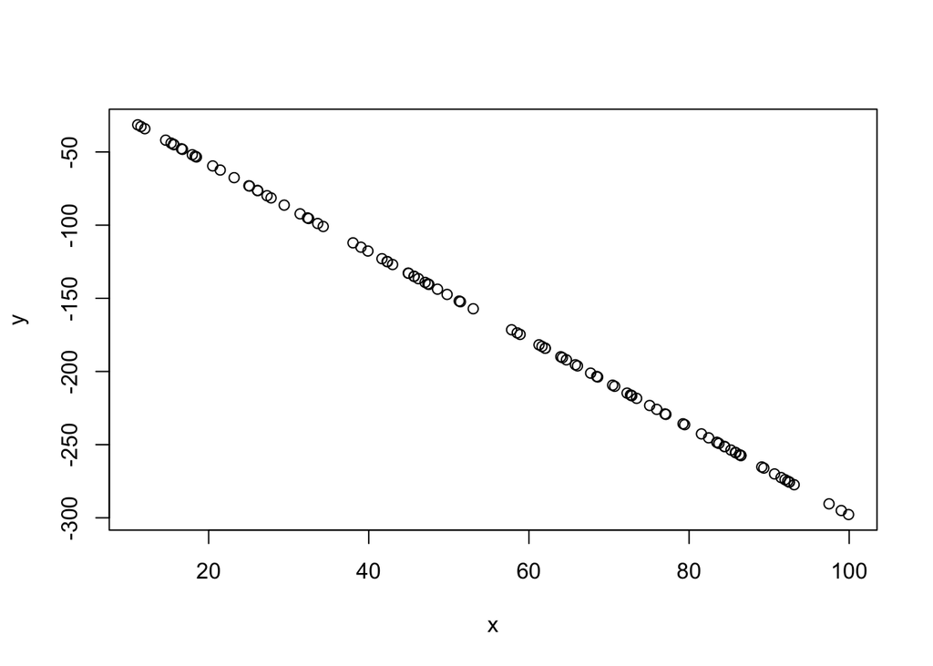

```r
N <- 100 #Total number of samples
alpha <- 2 #Value for alpha parameter
beta <- -3 #Values for beta parameter

#enter the command '?rnorm' into r to see what rnorm does if you are unsure.
x <- runif(N, 10, 100)
y <-  alpha + beta * x #Model

#Plot our simulated data
plot(x, y)
```

# Produce data to model II: Random Error Variable

Now we will add some normally distributed random vairable, $\epsilon$ to our model. The model should now be of the form:

$y_n = \alpha + \beta x_n + \epsilon_n$

$\epsilon_n \sim \mathcal{N}(0,\sigma)$

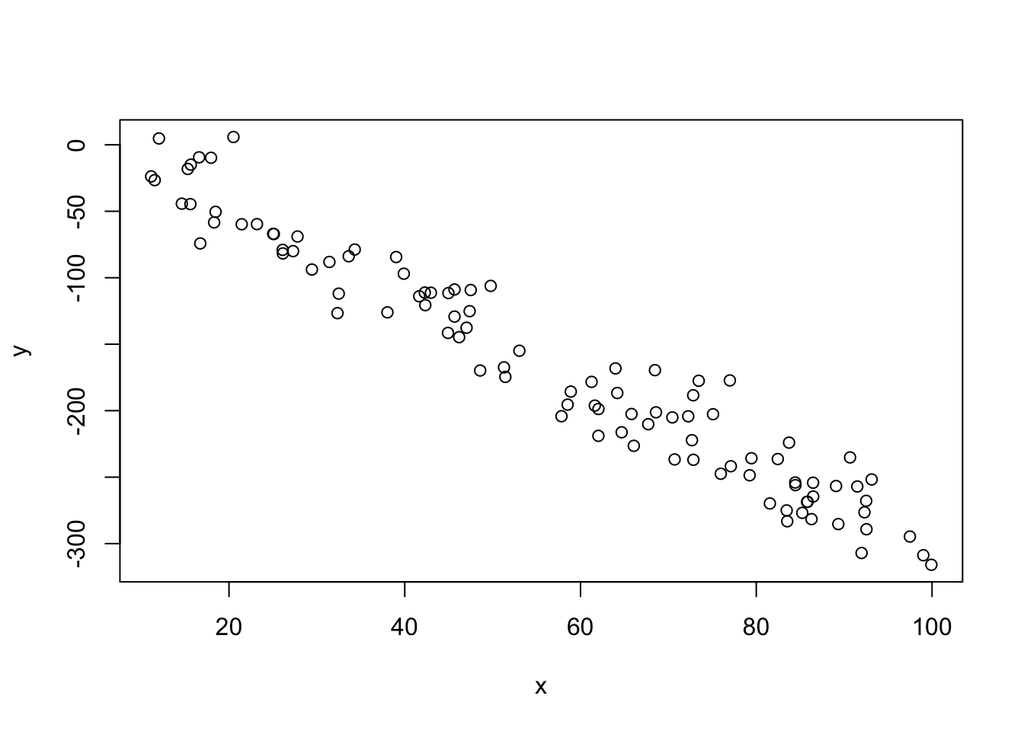

```r
epsilon <- rnorm(N, 0,20)
y <- alpha + beta * x + epsilon
plot(x, y)
```

# Stan Code

We now want to write some stan code to fit to these data. We can either save our stan code as a seperate file, or put it as a string here.

We could write this model in a couple of ways. The first involves a for loop over the data.

```r
stanProg <-
'data{
  int<lower=0> N;
  vector[N] x;
  vector[N] y;
}
parameters{
  real alpha;
  real beta;
  real<lower=0> sigma;
}
model{
  for (n in 1:N)
    y[n] ~ normal(alpha + beta * x[n], sigma);
}'
```

And the second involves a vectorised expression of the model used in the first example. This version of the model will be more efficient to run.

```r
stanProg <-
'data{
  int<lower=0> N;
  vector[N] x;
  vector[N] y;
}
parameters{
  real alpha;
  real beta;
  real<lower=0> sigma;
}
model{
    y ~ normal(alpha + beta * x, sigma);
}'
```

Now, let’s execute the stan code:

```r
fit <- stan(model_code=stanProg, data=c("N", "x", "y"))
```

[output not shown]

[output cut: 8 more lines]

[output not shown]

# Model Results

Let’s begin by printing out the results of the model fit.

```r
print(fit)
```

```
## Inference for Stan model: 0f7ae937de824da00357888effae5b32.
## 4 chains, each with iter=2000; warmup=1000; thin=1;
## post-warmup draws per chain=1000, total post-warmup draws=4000.
##
##          mean se_mean   sd    2.5%     25%     50%     75%   97.5% n_eff
## alpha   16.26    0.13 5.05    6.46   12.83   16.20   19.67   26.12  1566
## beta    -3.23    0.00 0.08   -3.38   -3.28   -3.22   -3.17   -3.07  1569
## sigma   20.78    0.03 1.47   18.21   19.71   20.66   21.75   23.89  2678
## lp__  -349.86    0.03 1.25 -353.13 -350.42 -349.56 -348.93 -348.43  1622
##       Rhat
## alpha    1
## beta     1
## sigma    1
## lp__     1
##
## Samples were drawn using NUTS(diag_e) at Fri Mar 24 11:05:41 2017.
## For each parameter, n_eff is a crude measure of effective sample size,
## and Rhat is the potential scale reduction factor on split chains (at
## convergence, Rhat=1).
```

As can be seen the mean of $\beta$, $\hat{\beta}$, is very close to the true parameter that we used to simulate our data, but the mean of $\alpha$, $\hat{\alpha}$, from our posterior is not paticularly precise. This is to be expected with this number of samples $(n)$. As we increase $n$, our $\hat{\alpha}\rightarrow\alpha$.

It can be useful to see how the different Monte Carlo chains arrived to these parameter estimates. We investigate this using a traceplot. Stan uses a number of warmup samples to explore the parameter space and is very efficient at doing so. Here are the parameter traceplots including the warmup samples:

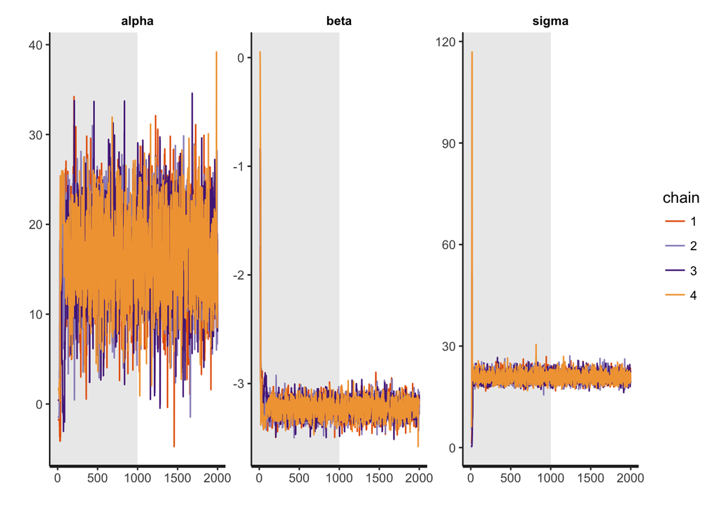

```r
traceplot(fit, inc_warmup=T)
```

And here are the traceplots excluding the warmup samples:

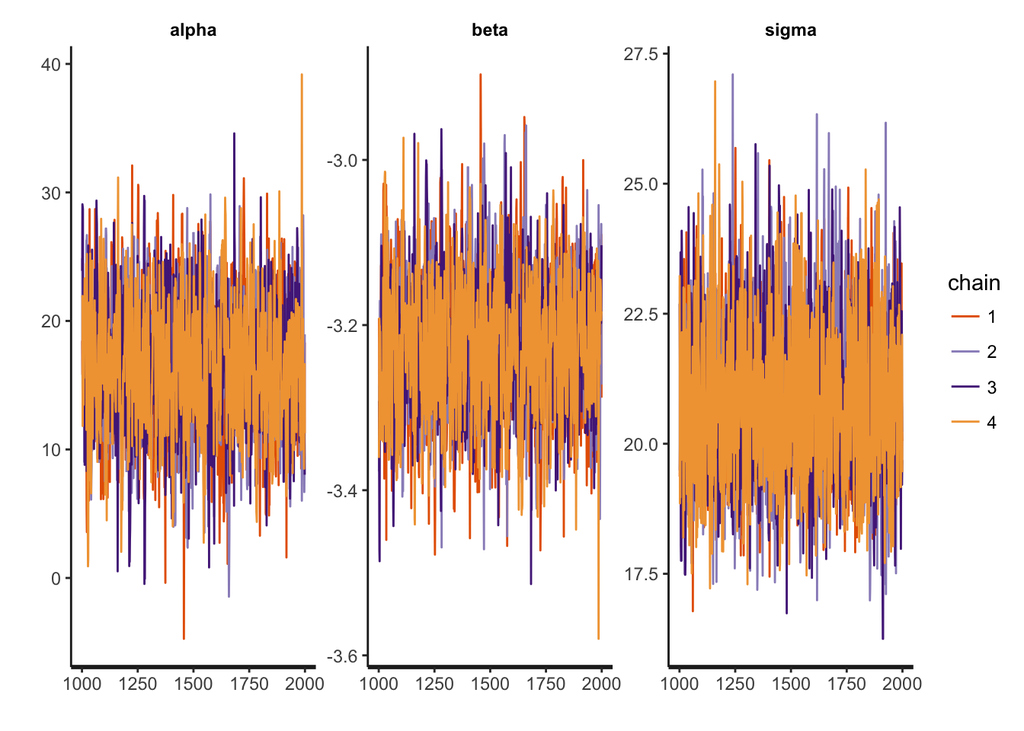

```r
traceplot(fit, inc_warmup=F)
```

We can also produce a pairs plot to investigate how our posteriors relate to one another:

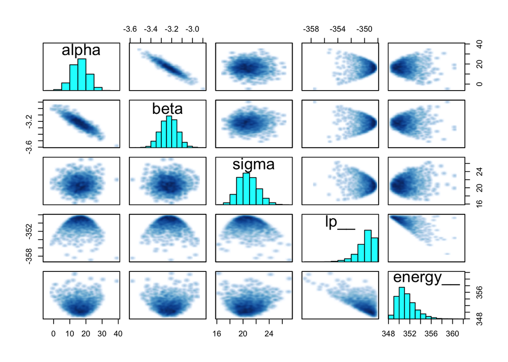

```r
pairs(fit)
```

# Posterior Predictive Checks

One of the most useful posterior predictive checks we can run is seeing whether our parameter estiamtes, $\hat{\alpha}$ & $\hat{\beta}$ are predictive of the data. To determine this, we can simply fit plot a straight line ontop of our simulated data, using the estimated values for our parameters. These values are very easy to extract from the fit object in rstan:

```r
alpha_hat <- mean(extract(fit)$alpha)
beta_hat <- mean(extract(fit)$beta)
```

Producing the following fit to our simulated data:

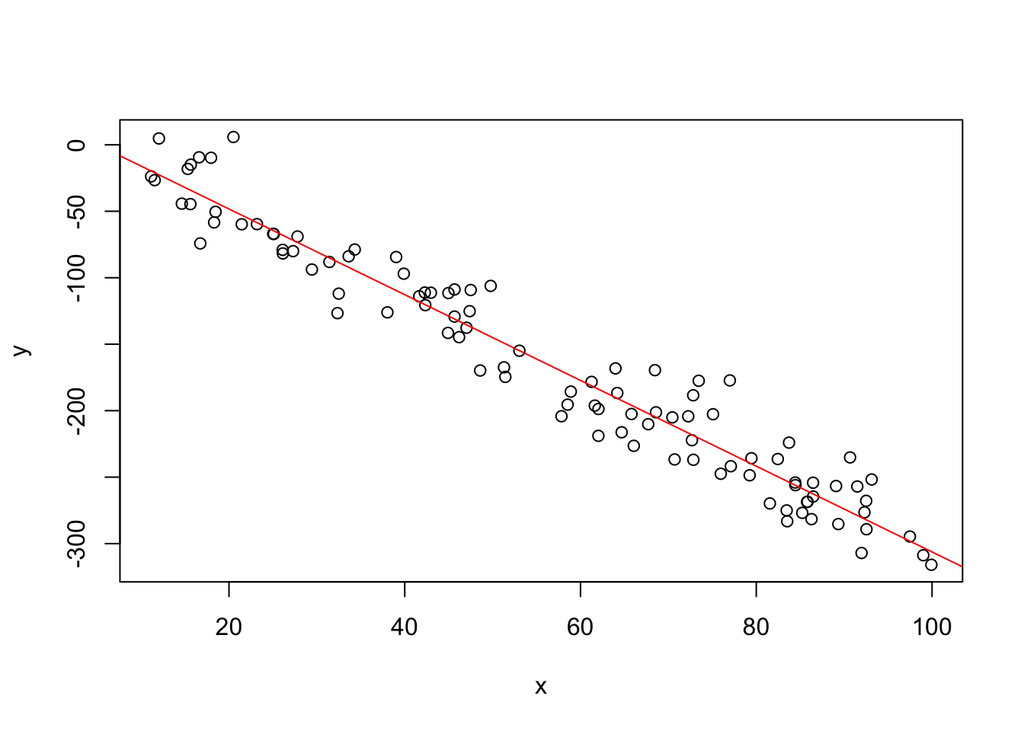

```r
plot(x,y)
abline(a=alpha_hat,b=beta_hat, col="red")
```

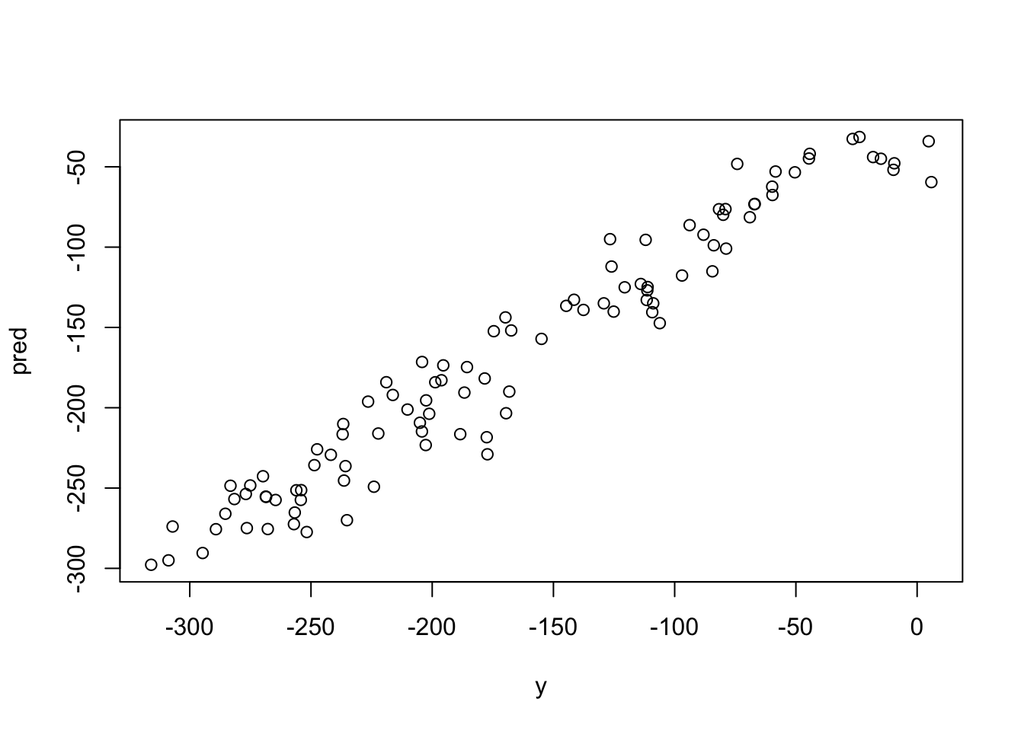

```r
pred <- alpha + beta * x
plot(y,pred)
```